# GAME_OF_THRONES

2022-12-02

### Expectations

Game of Thrones is a book about warfare and rivalry concerning claims of the throne. Therefore I expect that the sentiment analysis to some degree will be predominantly negative, since warfare is mostly related to negative sentiments. While it it also a story of brotherhood and alliances I expect positive sentiments related to this, to be present in the analysis as well. As a disclaimer I must state that I haven’t read the book myself, so these expectations are mainly based on my prejudices and for what I have been able to retrieve by Google’ing the subject.

### Get the Game of Thrones PDF

I will start by retrieving the PDF:

```r
got_path <- here("data","got.pdf")
got_text <- pdf_text(got_path)
```

### Some wrangling to split up pages into separate lines:

- Split up pages into separate lines (separated by `\n`) using `stringr::str_split()`
- Unnest into regular columns using `tidyr::unnest()`
- Remove leading/trailing white space with `stringr::str_trim()`

```r
got_df <- data.frame(got_text) %>%
  mutate(text_full = str_split(got_text, pattern = '\\n')) %>%
  unnest(text_full) %>%
  mutate(text_full = str_trim(text_full))
```

Now each line, on each page, is its own row, with extra starting & trailing spaces removed.

### Get the tokens (individual words) in tidy format

Use `tidytext::unnest_tokens()`, to split columns into tokens. We are interested in *words*, so that’s the token we’ll use:

```r
got_tokens <- got_df %>%
  unnest_tokens(word, text_full)
```

Let’s count the words!

```r
got_wc <- got_tokens %>%
  count(word) %>%
  arrange(-n)
got_wc
```

```
## # A tibble: 11,826 × 2
##    word      n
##    <chr> <int>
##  1 the   17988
##  2 and    8997
##  3 to     6640
##  4 a      6461
##  5 of     6200
##  6 he     5166
##  7 his    5161
##  8 was    3904
##  9 her    3659
## 10 you    3267
## # … with 11,816 more rows
```

### Remove stop words:

By removing stopwords, the less interesting words like “the” and “to” etc., disappear in favor of a core of more meaningful words, that will emerge afterwards

We will *remove* stop words using `tidyr::anti_join()`:

```r
got_stop <- got_tokens %>%
  anti_join(stop_words) %>%
  select(-got_text)
```

Now check the counts again:

```r
got_swc <- got_stop %>%
  count(word) %>%
  arrange(-n)
```

What if we want to get rid of all the numbers (non-text) in `got_stop`?

```r
got_no_numeric <- got_stop %>%
  filter(is.na(as.numeric(word)))
```

### A word cloud of the top 100 most frequent words in Game of Thrones

See more: https://cran.r-project.org/web/packages/ggwordcloud/vignettes/ggwordcloud.html

```r
# First I can count the amount of unique words
length(unique(got_no_numeric$word))
```

```
## [1] 11209
```

```r
# The number of unique words is 11.209, but I only want to include the 100 most freqeuent words:
got_top100 <- got_no_numeric %>%
  count(word) %>%
  arrange(-n) %>%
  head(100)
```

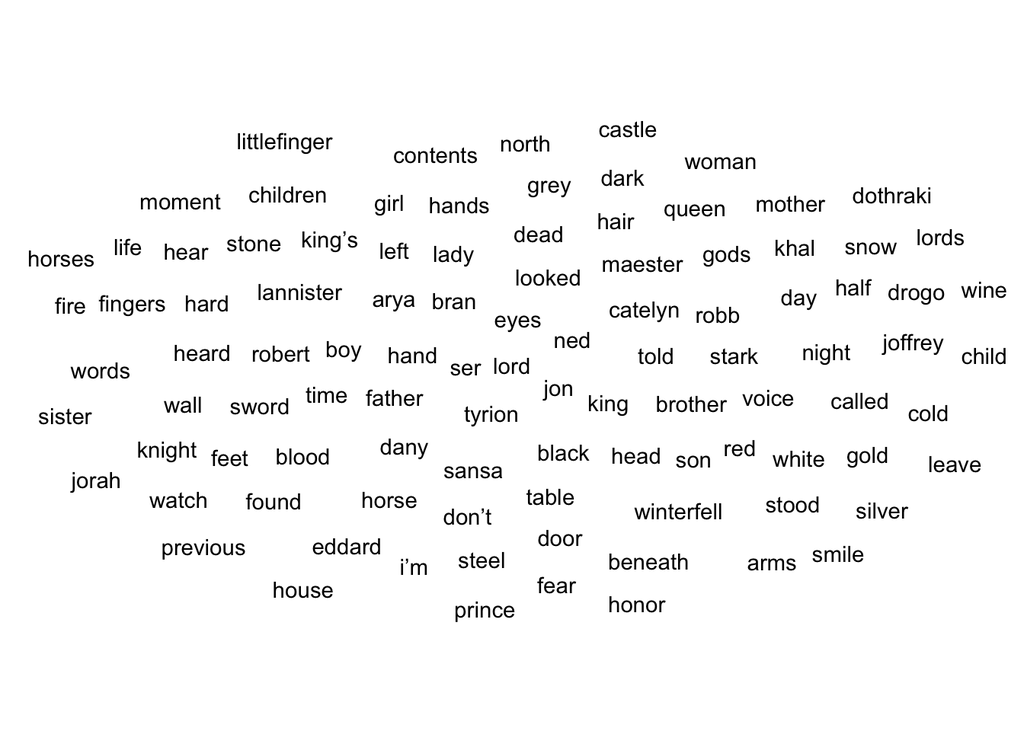

```r
got_cloud <- ggplot(data = got_top100, aes(label = word)) +
  geom_text_wordcloud() +
  theme_minimal()

got_cloud
```

In order to arrange the words so the most frequent words appear more visible than the less frequent words I use color and font size as a highlighter:

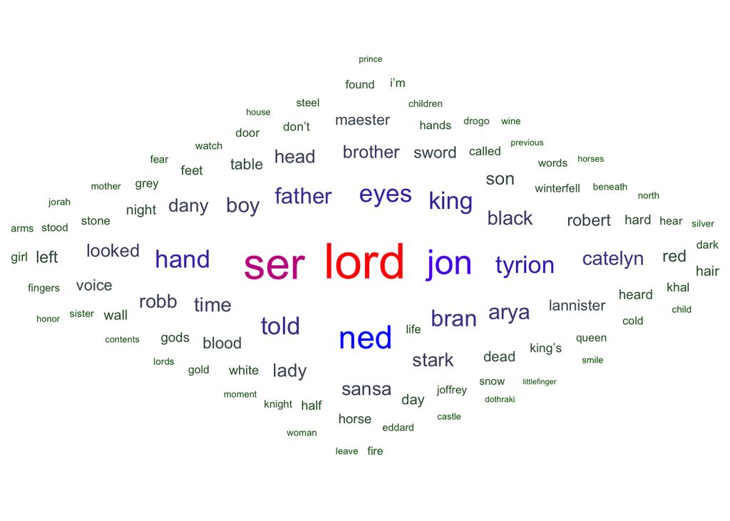

```r
ggplot(data = got_top100, aes(label = word, size = n)) +
  geom_text_wordcloud_area(aes(color = n), shape = "diamond") +
  scale_size_area(max_size = 12) +
  scale_color_gradientn(colors = c("darkgreen","blue","red")) +
  theme_minimal()
```

Thereby it is easier for the eye to sort out which words are most frequently appearing and therefore interesting, e.g. words like “lord”, “father”, “hand” etc.

## Sentiment analysis

For the Sentiment analysis I will be using the following three general-purpose lexica: - AFINN from Finn Årup Nielsen, - bing from Bing Liu and collaborators, and - nrc from Saif Mohammad and Peter Turney

### Applying the “afinn” lexicon to Game of Thrones

“afinn”: Words ranked from -5 (very negative) to +5 (very positive)

```r
get_sentiments(lexicon = "afinn")
```

```
## # A tibble: 2,477 × 2
##    word       value
##    <chr>      <dbl>
##  1 abandon       -2
##  2 abandoned     -2
##  3 abandons      -2
##  4 abducted      -2
##  5 abduction     -2
##  6 abductions    -2
##  7 abhor         -3
##  8 abhorred      -3
##  9 abhorrent     -3
## 10 abhors        -3
## # … with 2,467 more rows
```

```r
# Note: may be prompted to download (yes)

# Let's look at the pretty positive words from the value +3 to +5:
afinn_pos <- get_sentiments("afinn") %>%
  filter(value %in% c(3,4,5))

afinn_pos
```

```
## # A tibble: 222 × 2
##    word         value
##    <chr>        <dbl>
##  1 admire           3
##  2 admired          3
##  3 admires          3
##  4 admiring         3
##  5 adorable         3
##  6 adore            3
##  7 adored           3
##  8 adores           3
##  9 affection        3
## 10 affectionate     3
## # … with 212 more rows
```

It’s seen that words like “thrilled” and “superb” falls into the +5 category, while being somewhat more positive, according to the afinn lexicon, than words like “sparkling” and “splendid” that falls into the +3 category.

### Applying the “bing” lexicon to Game of Thrones

The bing lexicon has a somewhat simpler way of grading the value of words into binary categories of either “positive” or “negative”. The list comes out as follows:

```r
get_sentiments(lexicon = "bing")
```

```
## # A tibble: 6,786 × 2
##    word        sentiment
##    <chr>       <chr>
##  1 2-faces     negative
##  2 abnormal    negative
##  3 abolish     negative
##  4 abominable  negative
##  5 abominably  negative
##  6 abominate   negative
##  7 abomination negative
##  8 abort       negative
##  9 aborted     negative
## 10 aborts      negative
## # … with 6,776 more rows
```

### Applying the “nrc” lexicon to Game of Thrones

This lexicon includes bins for 8 emotions (anger, anticipation, disgust, fear, joy, sadness, surprise, trust) and positive / negative.

**Citation for NRC lexicon**: Crowdsourcing a Word-Emotion Association Lexicon, Saif Mohammad and Peter Turney, Computational Intelligence, 29 (3), 436-465, 2013.

Now nrc:

```r
get_sentiments(lexicon = "nrc")
```

```
## # A tibble: 13,872 × 2
##    word        sentiment
##    <chr>       <chr>
##  1 abacus      trust
##  2 abandon     fear
##  3 abandon     negative
##  4 abandon     sadness
##  5 abandoned   anger
##  6 abandoned   fear
##  7 abandoned   negative
##  8 abandoned   sadness
##  9 abandonment anger
## 10 abandonment fear
## # … with 13,862 more rows
```

It appears that the word “abandon” falls into three categories (“fear,”negative”,“sadness”), so the nrc lexicon seems somewhat more detailed.

### Sentiment analysis with afinn using the afinn and nrc lexica:

First, bind words in `got_stop` to `afinn` lexicon:

```r
got_afinn <- got_stop %>%
  inner_join(get_sentiments("afinn"))
```

Let’s find some counts (by sentiment ranking):

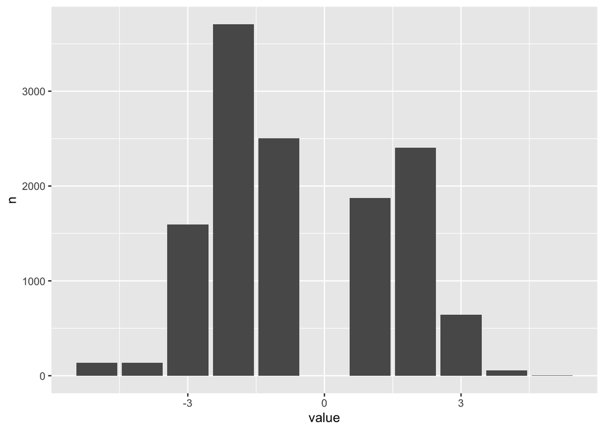

```r
got_afinn_hist <- got_afinn %>%
  count(value)

# Plot them:
ggplot(data = got_afinn_hist, aes(x = value, y = n)) +
  geom_col()
```

It appears that the words used in Game of Thrones are slightly more negative as especially the -2 category words are very frequent Therefore it is interesting to have a look at which words are actually in this -2 category

```r
got_afinn2 <- got_afinn %>%
  filter(value == -2)
```

It apperas that the -2 category contains words like “fire”, “nervous”, “fear” and “haunted”, which certainly all has a negative meaning to some extent

```r
# Check the unique 2-score words:
unique(got_afinn2$word)
```

```
##   [1] "fire"           "nervous"        "fear"           "haunted"
##   [5] "trouble"        "bored"          "distracted"     "interrupt"
##   [9] "fallen"         "enemy"          "steals"         "pain"
##  [13] "weak"           "sullen"         "weeping"        "careless"
##  [17] "wrong"          "afraid"         "warned"         "fool"
##  [21] "enemies"        "slashed"        "abandoned"      "failure"
##  [25] "trembling"      "death"          "screaming"      "clash"
##  [29] "cried"          "mocking"        "slash"          "shattered"
##  [33] "scream"         "ruin"           "sentence"       "struggling"
##  [37] "mistake"        "hurt"           "sad"            "troubled"
##  [41] "tears"          "bore"           "wasting"        "neglect"
##  [45] "gloomy"         "stubborn"       "brooding"       "melancholy"
##  [49] "deny"           "doom"           "poor"           "dread"
##  [53] "helpless"       "grief"          "lonely"         "frightened"
##  [57] "fail"           "steal"          "threatened"     "stolen"
```

[output cut: 82 more lines]

[figure not shown]

```r
# Count & plot them
got_afinn2_n <- got_afinn2 %>%
  count(word, sort = TRUE) %>%
  mutate(word = fct_reorder(factor(word), n))


ggplot(data = got_afinn2_n, aes(x = word, y = n)) +
  geom_col() +
  coord_flip()
```

Summarizing the sentiment of Game of Thrones using the afinn lexicon:

```r
got_summary <- got_afinn %>%
  summarize(
    mean_score = mean(value),
    median_score = median(value)
  )
```

With the mean score being -0,54 an the median score being -1, it can be concluded that the sentiment of this Game of Thrones book is slightly negative, which is about equivalent to my expectations, since the book is about warfare.

### Using the NRC lexicon for sentiment analysis

The NRC lexicon

We can use the NRC lexicon to start “binning” text by the feelings they’re typically associated with. As above, we’ll use inner_join() to combine the got non-stopword text with the nrc lexicon:

```r
got_nrc <- got_stop %>%
  inner_join(get_sentiments("nrc"))
```

By using `anti_join()` it is possible to check which words are excluded:

```r
got_exclude <- got_stop %>%
  anti_join(get_sentiments("nrc"))

# View(got_exclude)

# Count to find the most excluded:
got_exclude_n <- got_exclude %>%
  count(word, sort = TRUE)

head(got_exclude_n)
```

```
## # A tibble: 6 × 2
##   word       n
##   <chr>  <int>
## 1 ser     1023
## 2 jon      787
## 3 ned      743
## 4 tyrion   591
## 5 eyes     567
## 6 hand     567
```

The words excluded are e.g. names (Jon and Tyrion) and the title “Ser”, which is given to knights in the Seven Kingdoms. The names and titles, I think, are better of excluded from the sentiment analysis, but it is important to notice which words are excluded

Now find some counts:

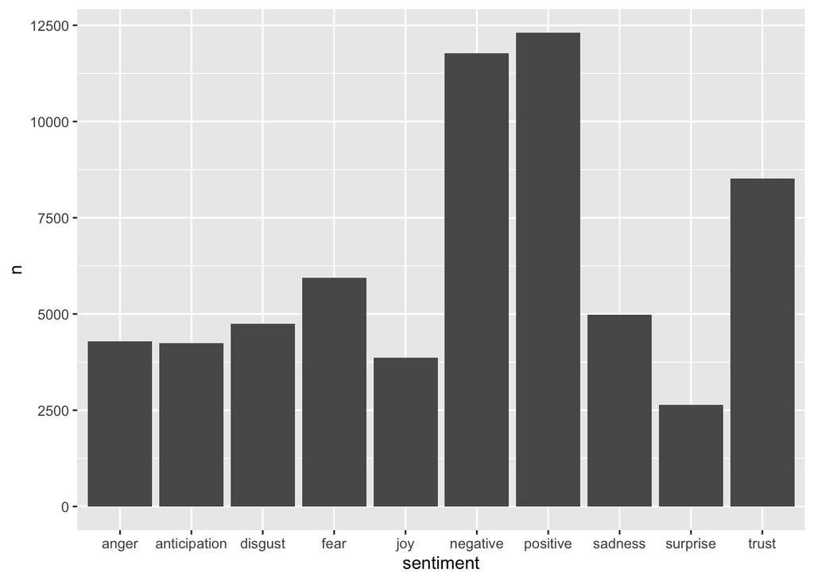

```r
got_nrc_n <- got_nrc %>%
  count(sentiment, sort = TRUE)

# And plot them:

ggplot(data = got_nrc_n, aes(x = sentiment, y = n)) +
  geom_col()
```

It can be seen that the two most frequent categories are “negative” and “positive”, which has about the same amount of counts, with the positive containting a little more counts. Since these to categories are contrary and has about the same count, I find it more interesting to look at the third and fourth categories, in terms of counts, which is “trust” and “fear”, that also stands out compared to the rest of the categories, which makes good sense in a book about warfare and alliances.

It is also possible to show the top 5 words under each of the 10 sentiment categories:

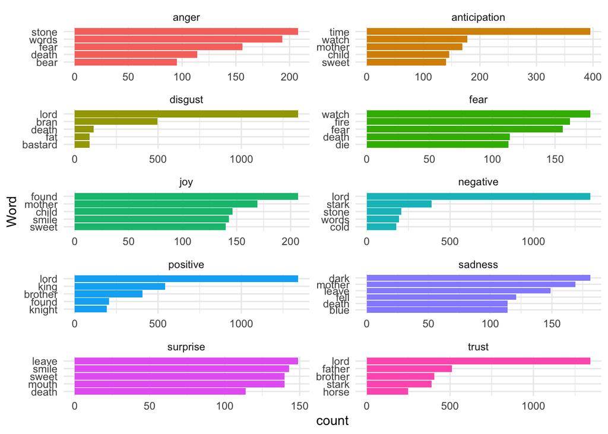

```r
got_nrc_n5 <- got_nrc %>%
  count(word,sentiment, sort = TRUE) %>%
  group_by(sentiment) %>%
  top_n(5) %>%
  ungroup()

got_nrc_gg <- ggplot(data = got_nrc_n5, aes(x = reorder(word,n), y = n, fill = sentiment)) +
  geom_col(show.legend = FALSE) +
  facet_wrap(~sentiment, ncol = 2, scales = "free") +
  coord_flip() +
  theme_minimal() +
  labs(x = "Word", y = "count")

# Show it
got_nrc_gg
```

```r
# Save it
ggsave(plot = got_nrc_gg,
       here("figures","got_nrc_sentiment.png"),
       height = 8,
       width = 5)
```

The word “lord” appears in 4 of the sentiment categories (disgust, negative, positive and trust). These categories have very different meanings, suggesting that the word “lord” can appear in very different contexts. Since the word “lord” appear so many times it heavily influence the four categories that it is categorized in. This is a good example of how one should consider whether a specific lexica is suitable for analyzing a given text. Looking at the different sentiment categories, I would say that, the overall impression is that the top 5 words suits the sentiment category rather good e.g. the sentiment category “joy” which contains the top 5 words “found”, “mother”, “child”, “smile” and “sweet”. There is, however, also examples of the opposite e.g. under the sentiment “anger” where the two most frequently apperearing words are “stone” and “words”, which don’t have anything particular to do with the sentiment “anger”.